# Guia Bolso

O GuiaBolso trabalha com diferentes parceiros para oferta de empréstimo pessoal para seus usuários. Para cada empréstimo fechado, o GuiaBolso ganha uma comissão. Atualmente, temos uma parceria com o Parceiro A e estamos avaliando uma parceria adicional com o Parceiro B. A comissão paga pelo Parceiro B seria metade do valor da comissão paga pelo Parceiro A por empréstimo. Gostaríamos que você emitisse uma opinião baseada em dados sobre qual deve ser o posicionamento do GuiaBolso: Ficar com ambos os parceiros, ficar só com o Parceiro A, ficar só com o Parceiro B.

Para avaliar essa possível parceria, pedimos para que os parceiros retornassem o score de crédito para uma amostra aleatória de usuários (Cada parceiro tem seu próprio método de calcular o score). Existem dois critérios que definem quem é ou não elegível para um empréstimo:

1. Score do usuário: o Parceiro A aprova usuários com score A > 770 (0 a 1000), e o Parceiro B aprova quem tem score B > 67 (0 a 100).
2. Categoria do usuário: os usuários são classificados em 6 categorias diferentes de acordo com seu perfil financeiro. Usuários da Categoria 1 não são elegíveis a empréstimo pelas regras do GuiaBolso.

```python
%matplotlib inline
import pandas as pd
import numpy as np
import matplotlib.pyplot as plt
import seaborn as sns
import statsmodels.formula.api as smf
import statsmodels.stats.multicomp as multi
import warnings
warnings.filterwarnings('ignore')
```

Procedimento:

1. Carregar os dados e normalizar o score B para um range de 0 a 1000
2. Calcular a diferença absoluta de score entre os parceiros dada uma determinada categoria

```python
data = pd.read_csv("data_emprestimo.csv", low_memory=False)
print data.head(5)
#Alterando a escala do Score B, basta multiplicar por 10.
data["Score Parceiro B"] = data["Score Parceiro B"].apply(lambda x : 10*x)
print data.head(5)
```

```
   user_id  Score Parceiro A  Score Parceiro B  Categoria GuiaBolso
0        1               977                97                    5
1        2               947                97                    5
2        3               760                97                    3
3        4               980                96                    5
4        5               977                96                    5
   user_id  Score Parceiro A  Score Parceiro B  Categoria GuiaBolso
0        1               977               970                    5
1        2               947               970                    5
2        3               760               970                    3
3        4               980               960                    5
4        5               977               960                    5
```

## 1) Qual a diferença média entre os scores A e B para cada categoria? Normalize o score B para um range de 0 a 1000.

```python
print data.head(5)
for categoria in range(1, 7):
    print "\nPara categoria " + str(categoria) + " as medias para A e B sao: ",
    meanA = data["Score Parceiro A"][data["Categoria GuiaBolso"] == categoria].mean()
    meanB = data["Score Parceiro B"][data["Categoria GuiaBolso"] == categoria].mean()
    print meanA,
    print " e " + str(meanB)
    print "Diferença média: " + str(abs(meanA - meanB))
```

```
   user_id  Score Parceiro A  Score Parceiro B  Categoria GuiaBolso
0        1               977               970                    5
1        2               947               970                    5
2        3               760               970                    3
3        4               980               960                    5
4        5               977               960                    5

Para categoria 1 as medias para A e B sao:  443.837980838  e 390.384670385
Diferença média: 53.4533104533

Para categoria 2 as medias para A e B sao:  336.16  e 244.488888889
Diferença média: 91.6711111111

Para categoria 3 as medias para A e B sao:  615.992277992  e 611.621621622
Diferença média: 4.37065637066

Para categoria 4 as medias para A e B sao:  830.337284483  e 684.612068966
Diferença média: 145.725215517

Para categoria 5 as medias para A e B sao:  938.95799458  e 792.77100271
Diferença média: 146.18699187

Para categoria 6 as medias para A e B sao:  955.021978022  e 811.69544741
Diferença média: 143.326530612
```

## Analisando se a parceria com B é vantajosa

A diferença entre scores é clara. Porém, o que vale é o critério de aprovação de cada parceira e não o Score por si só.

Como B paga uma comissão menor, uma parceria seria vantajosa se B concedesse empréstimo aos clientes que A não aprova, ou seja, operasse em outro nicho. Sem tomar negócios que já são cobertos por A e rendem o dobro de comissão.

Procedimento:

1. Vamos criar uma coluna para dizer se aquele usuario seria aprovado pelo parceiro A e outra para o parceiro B.
2. Vamos alterar a normalização do Score para que ele reflita também o critério de aprovação.

```python
#Adicionando colunas de aprovacao
data["A Aprova"] = data["Score Parceiro A"].apply(lambda x : 1 if x > 770 else 0)
data["B Aprova"] = data["Score Parceiro B"].apply(lambda x : 1 if x > 670 else 0)

#Modificando o Score B
from sklearn import preprocessing
scaler = preprocessing.MinMaxScaler(feature_range=(0, 769))
scaler = scaler.fit([x for x in range(0, 670)])
data["Score Parceiro B"][data["B Aprova"] == 0] = scaler.transform(data["Score Parceiro B"][data["B Aprova"] == 0])

scaler = preprocessing.MinMaxScaler(feature_range=(770, 1000))
scaler = scaler.fit([x for x in range(670, 1001)])
data["Score Parceiro B"][data["B Aprova"] == 1] = scaler.transform(data["Score Parceiro B"][data["B Aprova"] == 1])

data["Score Parceiro B"] = data["Score Parceiro B"].apply(lambda x : int(x))
print data.head(5)
```

```
   user_id  Score Parceiro A  Score Parceiro B  Categoria GuiaBolso  A Aprova  \
0        1               977               979                    5         1
1        2               947               979                    5         1
2        3               760               979                    3         0
3        4               980               972                    5         1
4        5               977               972                    5         1

   B Aprova
0         1
1         1
2         1
3         1
4         1
```

```python
print data.head(5)
for categoria in range(1, 7):
    print "\nPara categoria " + str(categoria) + " as medias para A e B sao: ",
    meanA = data["Score Parceiro A"][data["Categoria GuiaBolso"] == categoria].mean()
    meanB = data["Score Parceiro B"][data["Categoria GuiaBolso"] == categoria].mean()
    print meanA,
    print " e " + str(meanB)
    print "Diferença média: " + str(abs(meanA - meanB))
```

```
   user_id  Score Parceiro A  Score Parceiro B  Categoria GuiaBolso  A Aprova  \
0        1               977               979                    5         1
1        2               947               979                    5         1
2        3               760               979                    3         0
3        4               980               972                    5         1
4        5               977               972                    5         1

   B Aprova
0         1
1         1
2         1
3         1
4         1

Para categoria 1 as medias para A e B sao:  443.837980838  e 424.101530102
Diferença média: 19.7364507365

Para categoria 2 as medias para A e B sao:  336.16  e 271.368888889
Diferença média: 64.7911111111

Para categoria 3 as medias para A e B sao:  615.992277992  e 670.355212355
Diferença média: 54.3629343629

Para categoria 4 as medias para A e B sao:  830.337284483  e 736.891163793
Diferença média: 93.4461206897

Para categoria 5 as medias para A e B sao:  938.95799458  e 834.485094851
Diferença média: 104.472899729

Para categoria 6 as medias para A e B sao:  955.021978022  e 849.521193093
Diferença média: 105.500784929
```

## Comparando como A e B dão score para clientes de determinadas categorias

Agora que normalizamos os Scores para estarem na mesma escala e refletirem um mesmo critério de aprovação. Agora queremos saber se a diferença entre as médias desses Scores pareados é estatisticamente relevante. Para isso, faremos um teste F para as médias de Score para cada categoria sob a hipótese nula de que elas são iguais.

```python
from scipy import stats

for categoria in range(1, 7):
    print "\nPara categoria " + str(categoria) + " as estatística F e o p-value são: ",
    print stats.f_oneway(data["Score Parceiro A"][data["Categoria GuiaBolso"] == categoria],
                    data["Score Parceiro B"][data["Categoria GuiaBolso"] == categoria])
```

```
Para categoria 1 as estatística F e o p-value são:  (12.58051605189976, 0.00039106448909692978)

Para categoria 2 as estatística F e o p-value são:  (6.6816078963731949, 0.010056373482794435)

Para categoria 3 as estatística F e o p-value são:  (12.572579738439906, 0.00040897803185344778)

Para categoria 4 as estatística F e o p-value são:  (95.370051332004195, 5.3008463076112229e-22)

Para categoria 5 as estatística F e o p-value são:  (327.30587785959608, 1.8445501721603091e-69)

Para categoria 6 as estatística F e o p-value são:  (146.34147390579923, 5.7692074086695415e-32)
```

Conclusão: o processo gerador de score para cada parceiro não é o mesmo, o único que passou perto disso foi a categoria dois, com um p-value pouco maior que 1%. Então, os parceiros A e B tem critérios diferentes de aprovação.

```python
data["A não quer, B quer"] = data.apply(lambda x : 1 if x["A Aprova"] == 0 and x["B Aprova"] == 1 else 0, axis=1)
print data.head(5)
```

```
   user_id  Score Parceiro A  Score Parceiro B  Categoria GuiaBolso  A Aprova  \
0        1               977               979                    5         1
1        2               947               979                    5         1
2        3               760               979                    3         0
3        4               980               972                    5         1
4        5               977               972                    5         1

   B Aprova  A não quer, B quer
0         1                   0
1         1                   0
2         1                   1
3         1                   0
4         1                   0
```

```python
data["A não quer, B quer"].sum()
```

```
1532
```

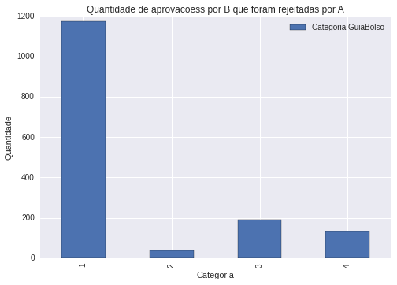

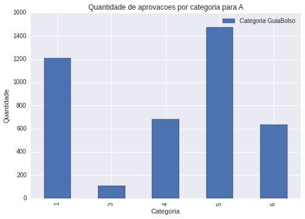

```
1    1175
2      37
3     189
4     131
Name: Categoria GuiaBolso, dtype: int64
4     680
1    1207
5    1475
6     637
3     110
Name: Categoria GuiaBolso, dtype: int64
1    6993
2     225
3     518
4     928
5    1476
6     637
Name: Categoria GuiaBolso, dtype: int64
```

```python
bar = pd.DataFrame(data["Categoria GuiaBolso"][data["A não quer, B quer"] == 1].convert_objects(convert_numeric=True).value_counts())
bar = bar.sort()
ax = bar.plot(kind='bar')
plt.ylabel("Quantidade")
plt.xlabel("Categoria")
plt.title('Quantidade de aprovacoess por B que foram rejeitadas por A')
plt.show()

bar = pd.DataFrame(data["Categoria GuiaBolso"][data["A Aprova"] == 1].convert_objects(convert_numeric=True).value_counts())
bar = bar.sort()
ax = bar.plot(kind='bar')
plt.ylabel("Quantidade")
plt.xlabel("Categoria")
plt.title('Quantidade de aprovacoes por categoria para A')
plt.show()

Bquer = data["Categoria GuiaBolso"][data["A não quer, B quer"] == 1].value_counts(sort=False)
print Bquer
Aapro = data["Categoria GuiaBolso"][data["A Aprova"] == 1].value_counts(sort=False)
print Aapro
total = data["Categoria GuiaBolso"].value_counts(sort=False)
print total
```

## Conclusão final

Porém, a diferença nos scores que cada parceira dá abre margem para a hipótese de que o montante aprovado seja proporcional ao score, o que poderia significar uma oportunidade. Sendo assim, mesmo que a comissão seja a metade, aprovando um montante maior, considerando que a comissão seja uma taxa sobre este, pode ser que utilizar a aprovação do parceiro B valha mais a pena do que a do A. Porém, scores maiores do parceiro B só aparecem, em média, para a categoria 3. Mesmo assim, é preciso analisar como é dada a comissão para tirar maiores conclusões nesse sentido.